# Investigate_a_Dataset

Udacity-Project: Investigate a Dataset - TMDB-Movies-Data

- Introduction
- Data Wrangling
- Exploratory Data Analysis
- Conclusions

## Introduction

### Overview

In this project we are using TMDB movies data to analyze dataset and communicate findings about it. To complete this project in easier way to write data analysis code, we will use Python libraries Numpy, pandas, Matplotlib, and seaborn.  
Research question that can analyzed from this data set:  
What is the profit for each movie?  
Which movies with most and least profit?  
Which movies with most and least revenue?  
Which movies with most and least budget?  
Which movies with longest and shortest runtime?  
Average runtime of the movies.  
Average budget of the movies.  
Average revenue of the movies.  
Release Year vs Profitability  
Number of movies per Genre  
Most cast in the movies.

```python
# Use this cell to set up import statements for all of the packages that you
#   plan to use.
import pandas as pd
import numpy as np
from datetime import datetime

# Remember to include a 'magic word' so that your visualizations are plotted
#   inline with the notebook. See this page for more:
#   http://ipython.readthedocs.io/en/stable/interactive/magics.html
import matplotlib.pyplot as plt
% matplotlib inline
import seaborn as sns
```

## Data Wrangling

After observing the dataset and research questions for the analysis, we will then delete unused data and keep the only relevant data.

### General Properties

```python
# Load your data and print out a few lines. Perform operations to inspect data
#   types and look for instances of missing or possibly errant data.
tmdb_data = pd.read_csv('tmdb-movies.csv')

#view first 5 rows
tmdb_data.head()
```

|  | id | imdb_id | popularity | budget | revenue | original_title | cast | homepage | director | tagline | ... | overview | runtime | genres | production_companies | release_date | vote_count | vote_average | release_year | budget_adj | revenue_adj |
| --- | --- | --- | --- | --- | --- | --- | --- | --- | --- | --- | --- | --- | --- | --- | --- | --- | --- | --- | --- | --- | --- |
| 0 | 135397 | tt0369610 | 32.985763 | 150000000 | 1513528810 | Jurassic World | Chris Pratt\|Bryce Dallas Howard\|Irrfan Khan\|Vi... | http://www.jurassicworld.com/ | Colin Trevorrow | The park is open. | ... | Twenty-two years after the events of Jurassic ... | 124 | Action\|Adventure\|Science Fiction\|Thriller | Universal Studios\|Amblin Entertainment\|Legenda... | 6/9/2015 | 5562 | 6.5 | 2015 | 137999939.3 | 1.392446e+09 |
| 1 | 76341 | tt1392190 | 28.419936 | 150000000 | 378436354 | Mad Max: Fury Road | Tom Hardy\|Charlize Theron\|Hugh Keays-Byrne\|Nic... | http://www.madmaxmovie.com/ | George Miller | What a Lovely Day. | ... | An apocalyptic story set in the furthest reach... | 120 | Action\|Adventure\|Science Fiction\|Thriller | Village Roadshow Pictures\|Kennedy Miller Produ... | 5/13/2015 | 6185 | 7.1 | 2015 | 137999939.3 | 3.481613e+08 |
| 2 | 262500 | tt2908446 | 13.112507 | 110000000 | 295238201 | Insurgent | Shailene Woodley\|Theo James\|Kate Winslet\|Ansel... | http://www.thedivergentseries.movie/#insurgent | Robert Schwentke | One Choice Can Destroy You | ... | Beatrice Prior must confront her inner demons ... | 119 | Adventure\|Science Fiction\|Thriller | Summit Entertainment\|Mandeville Films\|Red Wago... | 3/18/2015 | 2480 | 6.3 | 2015 | 101199955.5 | 2.716190e+08 |
| 3 | 140607 | tt2488496 | 11.173104 | 200000000 | 2068178225 | Star Wars: The Force Awakens | Harrison Ford\|Mark Hamill\|Carrie Fisher\|Adam D... | http://www.starwars.com/films/star-wars-episod... | J.J. Abrams | Every generation has a story. | ... | Thirty years after defeating the Galactic Empi... | 136 | Action\|Adventure\|Science Fiction\|Fantasy | Lucasfilm\|Truenorth Productions\|Bad Robot | 12/15/2015 | 5292 | 7.5 | 2015 | 183999919.0 | 1.902723e+09 |
| 4 | 168259 | tt2820852 | 9.335014 | 190000000 | 1506249360 | Furious 7 | Vin Diesel\|Paul Walker\|Jason Statham\|Michelle ... | http://www.furious7.com/ | James Wan | Vengeance Hits Home | ... | Deckard Shaw seeks revenge against Dominic Tor... | 137 | Action\|Crime\|Thriller | Universal Pictures\|Original Film\|Media Rights ... | 4/1/2015 | 2947 | 7.3 | 2015 | 174799923.1 | 1.385749e+09 |

5 rows × 21 columns

```python
#view number of columns and rows
tmdb_data.shape
```

```
(10866, 21)
```

```python
#check null values
tmdb_data.info()
```

```
<class 'pandas.core.frame.DataFrame'>
RangeIndex: 10866 entries, 0 to 10865
Data columns (total 21 columns):
id                      10866 non-null int64
imdb_id                 10856 non-null object
popularity              10866 non-null float64
budget                  10866 non-null int64
revenue                 10866 non-null int64
original_title          10866 non-null object
cast                    10790 non-null object
homepage                2936 non-null object
director                10822 non-null object
tagline                 8042 non-null object
keywords                9373 non-null object
overview                10862 non-null object
runtime                 10866 non-null int64
genres                  10843 non-null object
production_companies    9836 non-null object
release_date            10866 non-null object
vote_count              10866 non-null int64
vote_average            10866 non-null float64
release_year            10866 non-null int64
budget_adj              10866 non-null float64
revenue_adj             10866 non-null float64
dtypes: float64(4), int64(6), object(11)
memory usage: 1.7+ MB
```

```python
tmdb_data.isnull().sum()
```

```
id                         0
imdb_id                   10
popularity                 0
budget                     0
revenue                    0
original_title             0
cast                      76
homepage                7930
director                  44
tagline                 2824
keywords                1493
overview                   4
runtime                    0
genres                    23
production_companies    1030
release_date               0
vote_count                 0
vote_average               0
release_year               0
budget_adj                 0
revenue_adj                0
dtype: int64
```

### Data Cleaning:

Observation:

```python
# After discussing the structure of the data and any problems that need to be
#   cleaned, perform those cleaning steps in the second part of this section.

#deleting unused columns
del_col=['id','imdb_id','homepage','tagline', 'keywords', 'overview', 'production_companies']

#delete the columns
tmdb_data = tmdb_data.drop(del_col,1)
```

```python
#forgot to delete popularity
#deleting
del_col=['popularity']

#delete the columns
tmdb_data = tmdb_data.drop(del_col,1)

#confirm correction with deleted columns
tmdb_data.head(1)
```

|  | budget | revenue | original_title | cast | director | runtime | genres | release_date | vote_count | vote_average | release_year | budget_adj | revenue_adj |
| --- | --- | --- | --- | --- | --- | --- | --- | --- | --- | --- | --- | --- | --- |
| 0 | 150000000 | 1513528810 | Jurassic World | Chris Pratt\|Bryce Dallas Howard\|Irrfan Khan\|Vi... | Colin Trevorrow | 124 | Action\|Adventure\|Science Fiction\|Thriller | 6/9/2015 | 5562 | 6.5 | 2015 | 137999939.3 | 1.392446e+09 |

```python
#remove duplicates
tmdb_data.drop_duplicates(inplace=True)
```

```python
#confirm correction with drop
sum(tmdb_data.duplicated())
```

```
0
```

```python
#confirm drop duplicate
tmdb_data.shape
```

```
(10865, 13)
```

```python
#change date format
tmdb_data['release_date'] = pd.to_datetime(tmdb_data['release_date'])

tmdb_data.head()
```

|  | budget | revenue | original_title | cast | director | runtime | genres | release_date | vote_count | vote_average | release_year | budget_adj | revenue_adj |
| --- | --- | --- | --- | --- | --- | --- | --- | --- | --- | --- | --- | --- | --- |
| 0 | 150000000 | 1513528810 | Jurassic World | Chris Pratt\|Bryce Dallas Howard\|Irrfan Khan\|Vi... | Colin Trevorrow | 124 | Action\|Adventure\|Science Fiction\|Thriller | 2015-06-09 | 5562 | 6.5 | 2015 | 137999939.3 | 1.392446e+09 |
| 1 | 150000000 | 378436354 | Mad Max: Fury Road | Tom Hardy\|Charlize Theron\|Hugh Keays-Byrne\|Nic... | George Miller | 120 | Action\|Adventure\|Science Fiction\|Thriller | 2015-05-13 | 6185 | 7.1 | 2015 | 137999939.3 | 3.481613e+08 |
| 2 | 110000000 | 295238201 | Insurgent | Shailene Woodley\|Theo James\|Kate Winslet\|Ansel... | Robert Schwentke | 119 | Adventure\|Science Fiction\|Thriller | 2015-03-18 | 2480 | 6.3 | 2015 | 101199955.5 | 2.716190e+08 |
| 3 | 200000000 | 2068178225 | Star Wars: The Force Awakens | Harrison Ford\|Mark Hamill\|Carrie Fisher\|Adam D... | J.J. Abrams | 136 | Action\|Adventure\|Science Fiction\|Fantasy | 2015-12-15 | 5292 | 7.5 | 2015 | 183999919.0 | 1.902723e+09 |
| 4 | 190000000 | 1506249360 | Furious 7 | Vin Diesel\|Paul Walker\|Jason Statham\|Michelle ... | James Wan | 137 | Action\|Crime\|Thriller | 2015-04-01 | 2947 | 7.3 | 2015 | 174799923.1 | 1.385749e+09 |

```python
#drop rows with any null values
tmdb_data.dropna(inplace=True)
tmdb_data.info()
```

```
<class 'pandas.core.frame.DataFrame'>
Int64Index: 10731 entries, 0 to 10865
Data columns (total 13 columns):
budget            10731 non-null int64
revenue           10731 non-null int64
original_title    10731 non-null object
cast              10731 non-null object
director          10731 non-null object
runtime           10731 non-null int64
genres            10731 non-null object
release_date      10731 non-null datetime64[ns]
vote_count        10731 non-null int64
vote_average      10731 non-null float64
release_year      10731 non-null int64
budget_adj        10731 non-null float64
revenue_adj       10731 non-null float64
dtypes: datetime64[ns](1), float64(3), int64(5), object(4)
memory usage: 1.1+ MB
```

```python
#confirm correction with dropna
tmdb_data.shape
```

```
(10731, 13)
```

## Exploratory Data Analysis

### Research Question 1: What is the profit for each movie?

```python
# Use this, and more code cells, to explore your data. Don't forget to add
#   Markdown cells to document your observations and findings.

#insert new column for profit value
tmdb_data.insert(2,'profit',tmdb_data['revenue']-tmdb_data['budget'])

#confirm correction with added column for 'profit'
tmdb_data.head(1)
```

|  | budget | revenue | profit | original_title | cast | director | runtime | genres | release_date | vote_count | vote_average | release_year | budget_adj | revenue_adj |
| --- | --- | --- | --- | --- | --- | --- | --- | --- | --- | --- | --- | --- | --- | --- |
| 0 | 150000000 | 1513528810 | 1363528810 | Jurassic World | Chris Pratt\|Bryce Dallas Howard\|Irrfan Khan\|Vi... | Colin Trevorrow | 124 | Action\|Adventure\|Science Fiction\|Thriller | 2015-06-09 | 5562 | 6.5 | 2015 | 137999939.3 | 1.392446e+09 |

### Research Question 2: Which movies with most and least profit

```python
#define the function
def calculate(column):
    #high profit
    high=tmdb_data[column].idxmax()
    high_data=pd.DataFrame(tmdb_data.loc[high])

    #low profit
    low=tmdb_data[column].idxmin()
    low_data=pd.DataFrame(tmdb_data.loc[low])

    #collect data
    data=pd.concat([high_data, low_data], axis=1)

    return data

calculate ('profit')
```

|  | 1386 | 2244 |
| --- | --- | --- |
| budget | 237000000 | 425000000 |
| revenue | 2781505847 | 11087569 |
| profit | 2544505847 | -413912431 |
| original_title | Avatar | The Warrior's Way |
| cast | Sam Worthington\|Zoe Saldana\|Sigourney Weaver\|S... | Kate Bosworth\|Jang Dong-gun\|Geoffrey Rush\|Dann... |
| director | James Cameron | Sngmoo Lee |
| runtime | 162 | 100 |
| genres | Action\|Adventure\|Fantasy\|Science Fiction | Adventure\|Fantasy\|Action\|Western\|Thriller |
| release_date | 2009-12-10 00:00:00 | 2010-12-02 00:00:00 |
| vote_count | 8458 | 74 |
| vote_average | 7.1 | 6.4 |
| release_year | 2009 | 2010 |
| budget_adj | 2.40887e+08 | 4.25e+08 |
| revenue_adj | 2.82712e+09 | 1.10876e+07 |

As you can see the original title movie 'Avatar' has the most profit of $2.54B and the movie 'The Warrior's Way' has the least profit of -413M dollars.

### Research Question 3: Which movies with most and least revenue.

```python
#lets do the same with revenue
calculate ('revenue')
```

|  | 1386 | 48 |
| --- | --- | --- |
| budget | 237000000 | 30000000 |
| revenue | 2781505847 | 0 |
| profit | 2544505847 | -30000000 |
| original_title | Avatar | Wild Card |
| cast | Sam Worthington\|Zoe Saldana\|Sigourney Weaver\|S... | Jason Statham\|Michael Angarano\|Milo Ventimigli... |
| director | James Cameron | Simon West |
| runtime | 162 | 92 |
| genres | Action\|Adventure\|Fantasy\|Science Fiction | Thriller\|Crime\|Drama |
| release_date | 2009-12-10 00:00:00 | 2015-01-14 00:00:00 |
| vote_count | 8458 | 481 |
| vote_average | 7.1 | 5.3 |
| release_year | 2009 | 2015 |
| budget_adj | 2.40887e+08 | 2.76e+07 |
| revenue_adj | 2.82712e+09 | 0 |

The movie 'Avatar' has the most revenue of $2.78B and the movie 'Wild Card' has the least of zero revenue.

### Research Question 4: Which movies with most and least budget.

```python
#lets do the same with budget
calculate ('budget')
```

|  | 2244 | 30 |
| --- | --- | --- |
| budget | 425000000 | 0 |
| revenue | 11087569 | 29355203 |
| profit | -413912431 | 29355203 |
| original_title | The Warrior's Way | Mr. Holmes |
| cast | Kate Bosworth\|Jang Dong-gun\|Geoffrey Rush\|Dann... | Ian McKellen\|Milo Parker\|Laura Linney\|Hattie M... |
| director | Sngmoo Lee | Bill Condon |
| runtime | 100 | 103 |
| genres | Adventure\|Fantasy\|Action\|Western\|Thriller | Mystery\|Drama |
| release_date | 2010-12-02 00:00:00 | 2015-06-19 00:00:00 |
| vote_count | 74 | 425 |
| vote_average | 6.4 | 6.4 |
| release_year | 2010 | 2015 |
| budget_adj | 4.25e+08 | 0 |
| revenue_adj | 1.10876e+07 | 2.70068e+07 |

The movie 'The Warrior's Way' has the most budget of $425M and the movie 'Mr. Holmes has the least of zero budget.

### Research Question 5: Which movies with longest and least runtime.

```python
#lets do the same with runtime
calculate ('runtime')
```

|  | 3894 | 92 |
| --- | --- | --- |
| budget | 0 | 0 |
| revenue | 0 | 0 |
| profit | 0 | 0 |
| original_title | The Story of Film: An Odyssey | Mythica: The Necromancer |
| cast | Mark Cousins\|Jean-Michel Frodon\|Cari Beauchamp... | Melanie Stone\|Adam Johnson\|Kevin Sorbo\|Nicola ... |
| director | Mark Cousins | A. Todd Smith |
| runtime | 900 | 0 |
| genres | Documentary | Fantasy\|Action\|Adventure |
| release_date | 2011-09-03 00:00:00 | 2015-12-19 00:00:00 |
| vote_count | 14 | 11 |
| vote_average | 9.2 | 5.4 |
| release_year | 2011 | 2015 |
| budget_adj | 0 | 0 |
| revenue_adj | 0 | 0 |

The movie 'The Story of Film: An Odyssey' with longest runtime of 900 minutes and movie 'Mythica: The Necromancer' with zero minutes.

### Research Question 6: Average runtime of the movies.

```python
#Let's check the average runtime
#new function to find average
def avg_run(column):
    return tmdb_data[column].mean()

#call the function for runtime
avg_run('runtime')
```

```
102.46882862734135
```

The average runtime is 102 minutes.

```python
#Let's check the average budget
#new function to find average
def profit_avg(column):
    return tmdb_data[column].mean()

#call the function for budget
profit_avg('budget')
```

```
14803646.144068586
```

The average budget is 14 million dollars.

### Research Question 8: Average revenue of the movies.

```python
#Let's check the average revenue
#new function to find average
def profit_avg(column):
    return tmdb_data[column].mean()

#call the function for revenue
profit_avg('revenue')
```

```
40319887.588016026
```

The average revenue is 40 million dollars.

### Research Question 9: Release Year vs Profitability

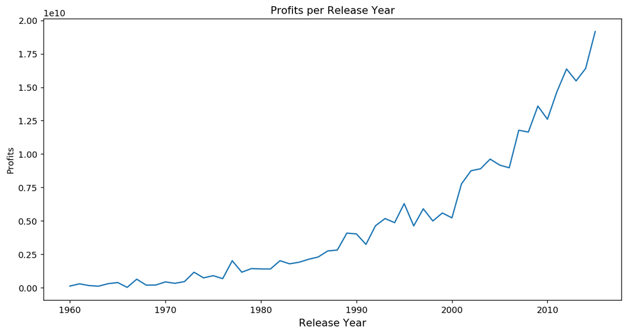

```python
#use a line plot
#sum up all the movies of a particular year
profits_per_year = tmdb_data.groupby('release_year')['profit'].sum()

#figure size(widht, height)
plt.figure(figsize=(12,6), dpi = 130)

#x axis
plt.xlabel('Release Year', fontsize = 12)
#y axis
plt.ylabel('Profits')
#title
plt.title('Profits per Release Year', fontsize = 12)
# plot graph
plt.plot(profits_per_year)

#display the plot
plt.show()
```

As you can see the distribution of the above graph is skewed on the right side towards higher profits per release year.

### Research Question 10: Number of movies per Genre

```python
# Continue to explore the data to address your additional research
#   questions. Add more headers as needed if you have more questions to
#   investigate.

#genres have more than one category and have string that holds multiple values. We need to separate the string.
#create a column for each genre - 1 if genre is in genres else 0

def genre_data(column):
#create a column and separate the string by '|'
    genre_data = tmdb_data[column].str.cat(sep = '|')
#use pandas series and store the values separately
    genre_data = pd.Series(genre_data.split('|'))
#arranging order to look clean
    count = genre_data.value_counts(ascending = False)

    return count

#variable to store the returned values
count = genre_data('genres')

#display all values
count.head
```

```
<bound method NDFrame.head of Drama              4746
Comedy             3775
Thriller           2902
Action             2376
Romance            1708
Horror             1636
Adventure          1465
Crime              1353
Science Fiction    1221
Family             1214
Fantasy             908
Mystery             808
Animation           664
Documentary         470
Music               399
History             330
War                 268
Foreign             184
Western             164
TV Movie            162
dtype: int64>
```

There are 20 types of category. You can see the 'Drama' category has the most number of 4,746 movies.

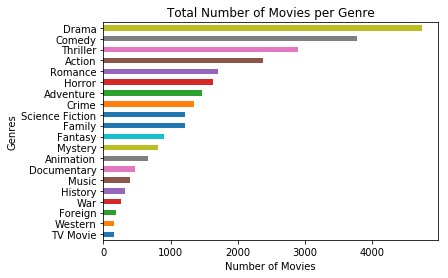

```python
#for a better visual of above data, lets plot the data in the same order.
count.sort_values(ascending = True, inplace = True)

#plot using plot.barh since we have quite few genres.
genre = count.plot.barh()
#title
genre.set(title = 'Total Number of Movies per Genre')
#label x axis
genre.set_xlabel('Number of Movies')
#label y axis
genre.set_ylabel('Genres')

#display the plot
plt.show()
```

### Research Question 11: Most cast in the movies.

```python
#again we need to call the same function data(column) for this analysis

#variable to store the returned value
count = genre_data('cast')

#display top 5 values
count.head()
```

```
Robert De Niro       72
Samuel L. Jackson    71
Bruce Willis         62
Nicolas Cage         61
Michael Caine        53
dtype: int64
```

Robert De Niro is on the top with total of 72 cast followed by Samuel L. Jackson with 71 and Bruce Willis with 62.

## Conclusions

> This is a very interesting data analysis and the facts about movies.

> Average budget must be around 14 million dollars.  
> Average movie runtime must be 102 minutes.  
> Genre must be Drama, Comedy, Thriller, Action  
> Always in the cast: Robert De Niro, Samuel L. Jackson, Bruce Willis, Nicholas Cage, Michael Cane.

```python
from subprocess import call
call(['python', '-m', 'nbconvert', 'Investigate_a_Dataset.ipynb'])
```

```
0
```